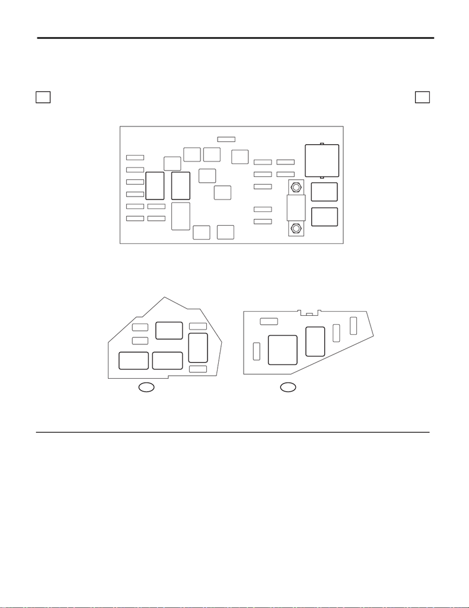

WI-20

Fuse And Relay

WIRING SYSTEM

3. Fuse And Relay

A: LOCATION

1. ENGINE TYPE FA (WITHOUT PUSH BUTTON START, ENGINE COMPARTMENT SIDE)

WI-44238

1a 1a

M/B

(5)

(3)

(4)

(1) (2)

(9)

(7)

(6)

(8)

F27

(1)

(2)

(8)

(4)

(5)

(6)

(3)

(7)

(9)

(10)

(11)

SBF-2SBF-6

SBF-8

MAIN

SBF

SBF-3

SBF-1

SBF-5

SBF-4

SBF-7

(11)

(10)

B564

HEADLIGHT RELAY LO

HEADLIGHT RELAY HI

MAIN FAN RELAY 2

BRAKE PUMP RELAY

FUEL INJECTOR RELAY

SUB FAN RELAY

DAYTIME RUNNING LIGHT RELAY

A/C RELAY

REAR DEFOGGER RELAY

MAIN FAN RELAY 1

HORN RELAY

RELAY HOLDER

No. 10

No. 9

No. 16

No. 15

No. 14

No. 13

No. 12

No. 11

No. 7

No. 6

No. 5

No. 2

No. 1

No. 4

No. 3

No. 8

RELAY HOLDER

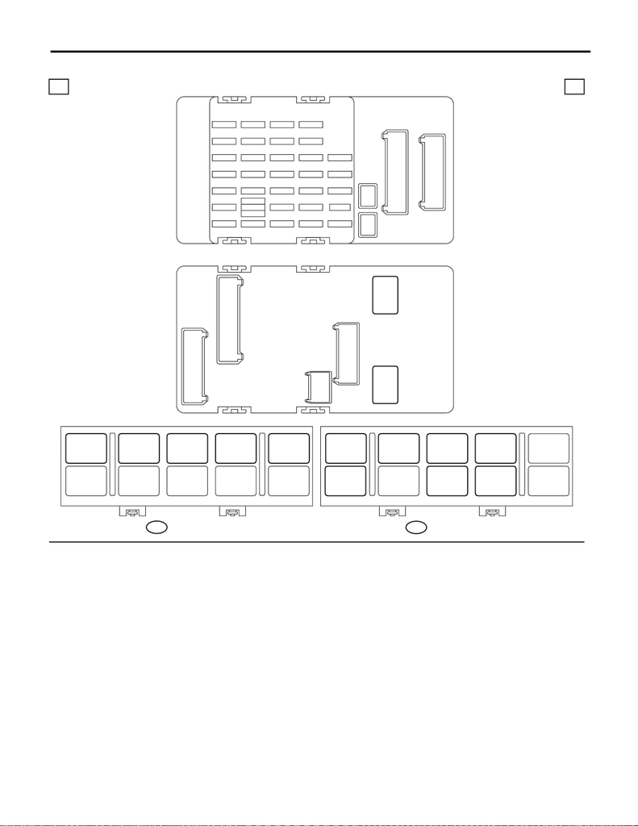

WI-21

Fuse And Relay

WIRING SYSTEM

2. ENGINE TYPE FA (WITHOUT PUSH BUTTON START, PASSENGER ROOM SIDE)

WI-44239

2a 2a

(3)

(4)

(5)

(6)

(7)

(11)

(9)

(8)

(12)

(14)

(13)

(10)

(1)

(2)

(1)

(2)

(6) (9)(5)(4) (7) (10)(8)

(12)

(11)

(13) (14)

(3)

B225

B220

RELAY HOLDERRELAY HOLDER

No. 5

No. 4

No. 3

No. 2

No. 1

No. 12

No. 11

No. 10

No. 9

No. 8

No. 7

No. 6

No. 19

No. 18

No. 17

No. 16

No. 15

No. 14

No. 13

No. 26

No. 25

No. 24

No. 23

No. 22

No. 21

No. 20

No. 33

No. 32

No. 31

No. 30

No. 29

No. 28

No. 27

F/B FRONT SIDE

F/B BACK SIDE

ACCESSORY RELAY

IG 2 RELAY

MAIN RELAY

WIPER DEICER RELAY

SEAT HEATER RELAY

FRONT FOG LIGHT RELAY

FUEL PUMP RELAY

IG RELAY

SELF SHUT RELAY

A/F, OXYGEN SENSOR RELAY

ELECTRONIC THROTTLE CONTROL RELAY

TAIL & ILLUMINATION RELAY

POWER WINDOW RELAY

STARTER RELAY 1

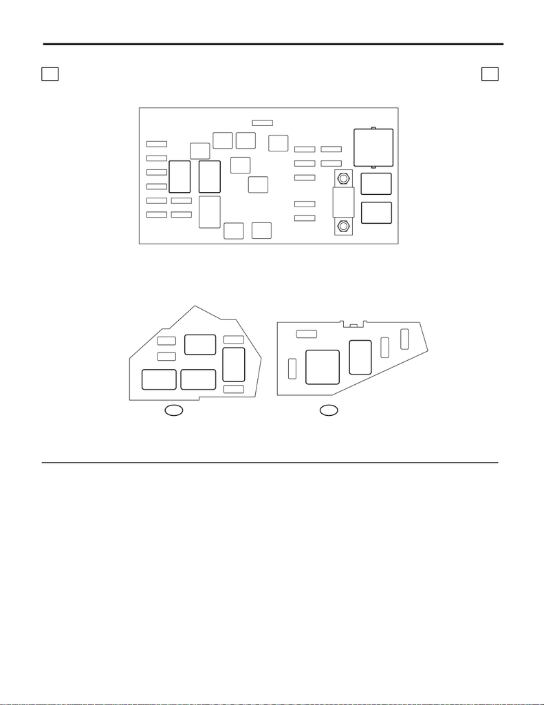

WI-22

Fuse And Relay

WIRING SYSTEM

3. ENGINE TYPE FA (WITH PUSH BUTTON START, ENGINE COMPARTMENT SIDE)

WI-44240

3a 3a

M/B

(5)

(3)

(4)

(1) (2)

(9)

(7)

(6)

(8)

F27

(1)

(2)

(8)

(4)

(5)

(6)

(3)

(7)

(9)

(10)

(11)

MAIN

SBF

SBF-3

SBF-1

SBF-5

SBF-4

SBF-7

SBF-2SBF-6

SBF-8

(11)

(10)

B564

HEADLIGHT RELAY LO

HEADLIGHT RELAY HI

MAIN FAN RELAY 2

BRAKE PUMP RELAY

FUEL INJECTOR RELAY

SUB FAN RELAY

DAYTIME RUNNING LIGHT RELAY

A/C RELAY

REAR DEFOGGER RELAY

MAIN FAN RELAY 1

HORN RELAY

RELAY HOLDER

No. 10

No. 9

No. 16

No. 15

No. 14

No. 13

No. 12

No. 11

No. 7

No. 6

No. 5

No. 2

No. 1

No. 4

No. 3

No. 8

RELAY HOLDER

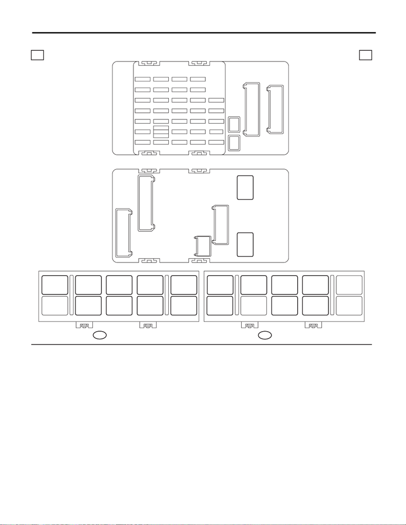

WI-23

Fuse And Relay

WIRING SYSTEM

4. ENGINE TYPE FA (WITH PUSH BUTTON START, PASSENGER ROOM SIDE)

WI-44241

4a 4a

(3)

(4)

(5)

(6)

(8)

(9)

(7)

(13)

(11)

(10)

(14)

(16)

(18)

(15)

(17)

(12)

(1)

(2)

(1)

(2)

(6) (13)(5)(4) (7)

(10)(9)(8) (11)

(14)(12)

(16)

(15)

(17) (18)

(3)

B225

B220

RELAY HOLDERRELAY HOLDER

No. 5

No. 4

No. 3

No. 2

No. 1

No. 12

No. 11

No. 10

No. 9

No. 8

No. 7

No. 6

No. 19

No. 18

No. 17

No. 16

No. 15

No. 14

No. 13

No. 26

No. 25

No. 24

No. 23

No. 22

No. 21

No. 20

No. 33

No. 32

No. 31

No. 30

No. 29

No. 28

No. 27

F/B FRONT SIDE

F/B BACK SIDE

ACCESSORY RELAY

IG 2 RELAY

FUEL PUMP RELAY

WIPER DEICER RELAY

SELF SHUT RELAY

SEAT HEATER RELAY

FRONT FOG LIGHT RELAY

MAIN RELAY

IG RELAY 1

STARTER CUT RELAY

IG RELAY

A/F, OXYGEN SENSOR RELAY

IG RELAY 2

STARTER RELAY (PUSH BUTTON START)

ELECTRONIC THROTTLE CONTROL RELAY

TAIL & ILLUMINATION RELAY

POWER WINDOW RELAY

STARTER RELAY 1

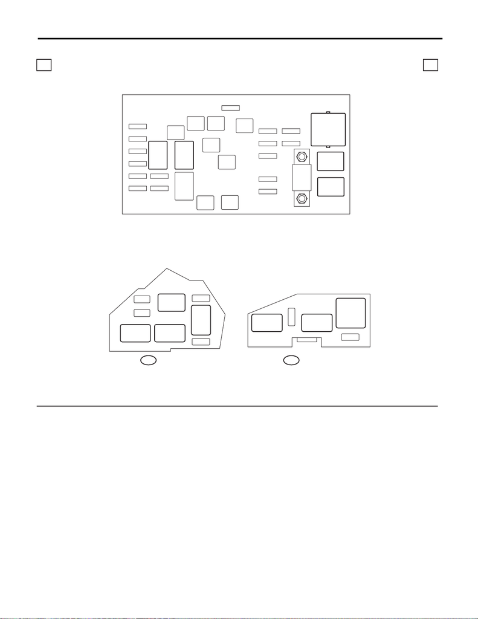

WI-24

Fuse And Relay

WIRING SYSTEM

5. ENGINE TYPE EJ (WITHOUT PUSH BUTTON START, ENGINE COMPARTMENT SIDE)

WI-44242

5a 5a

M/B

(5)

(3)

(4)

(1) (2)

(9)

(7)

(6)

(8)

F27

(1)

(2)

(8)

(4)

(5)

(6)

(3)

(7)

(9)

(10)

(11)

(12)

SBF-2SBF-6

SBF-8

MAIN

SBF

SBF-3

SBF-1

SBF-5

SBF-4

SBF-7

(12)

(11)(10)

F9

HEADLIGHT RELAY LO

HEADLIGHT RELAY HI

DAYTIME RUNNING LIGHT RELAY

MAIN FAN RELAY 2

AIR CUT RELAY 1

AIR CUT RELAY 2

AIR PUMP RELAY

SUB FAN RELAY

A/C RELAYREAR DEFOGGER RELAY

MAIN FAN RELAY 1

HORN RELAY

RELAY HOLDER

No. 10

No. 9

No. 16

No. 15

No. 14

No. 13

No. 12

No. 11

No. 7

No. 6

No. 5

No. 2

No. 1

No. 4

No. 3

No. 8

RELAY HOLDER

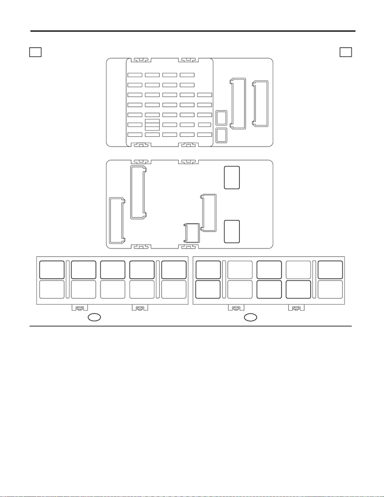

WI-25

Fuse And Relay

WIRING SYSTEM

6. ENGINE TYPE EJ (WITHOUT PUSH BUTTON START, PASSENGER ROOM SIDE)

WI-44243

6a 6a

(3)

(4)

(5)

(6)

(7)

(11)

(9)

(8)

(12)

(13)

(10)

(1)

(2)

(1)

(2)

(6)(5)(4) (7) (9)(8)

(11)

(10)

(12) (13)

(3)

B225

B220

RELAY HOLDERRELAY HOLDER

No. 5

No. 4

No. 3

No. 2

No. 1

No. 12

No. 11

No. 10

No. 9

No. 8

No. 7

No. 6

No. 19

No. 18

No. 17

No. 16

No. 15

No. 14

No. 13

No. 26

No. 25

No. 24

No. 23

No. 22

No. 21

No. 20

No. 33

No. 32

No. 31

No. 30

No. 29

No. 28

No. 27

F/B FRONT SIDE

F/B BACK SIDE

ACCESSORY RELAY

IG 2 RELAY

DCCD RELAY

SEAT HEATER RELAY

WIPER DEICER RELAY

FUEL PUMP RELAY

MAIN RELAY

FRONT FOG LIGHT RELAY

A/F, OXYGEN SENSOR RELAY

ELECTRONIC THROTTLE CONTROL RELAY

TAIL & ILLUMINATION RELAY

POWER WINDOW RELAY

STARTER RELAY 1

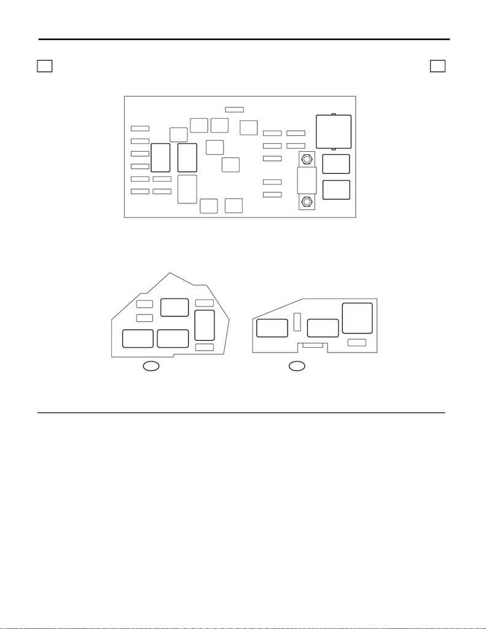

WI-26

Fuse And Relay

WIRING SYSTEM

7. ENGINE TYPE EJ (WITH PUSH BUTTON START, ENGINE COMPARTMENT SIDE)

WI-44244

7a 7a

M/B

(5)

(3)

(4)

(1) (2)

(9)

(7)

(6)

(8)

F27

(1)

(2)

(8)

(4)

(5)

(6)

(3)

(7)

(9)

(10)

(11)

(12)

MAIN

SBF

SBF-3

SBF-1

SBF-5

SBF-4

SBF-7

SBF-2SBF-6

SBF-8

(12)

(11)(10)

F9

HEADLIGHT RELAY LO

HEADLIGHT RELAY HI

DAYTIME RUNNING LIGHT RELAY

MAIN FAN RELAY 2

AIR CUT RELAY 1

AIR CUT RELAY 2

AIR PUMP RELAY

SUB FAN RELAY

A/C RELAYREAR DEFOGGER RELAY

MAIN FAN RELAY 1

HORN RELAY

RELAY HOLDER

No. 10

No. 9

No. 16

No. 15

No. 14

No. 13

No. 12

No. 11

No. 7

No. 6

No. 5

No. 2

No. 1

No. 4

No. 3

No. 8

RELAY HOLDER

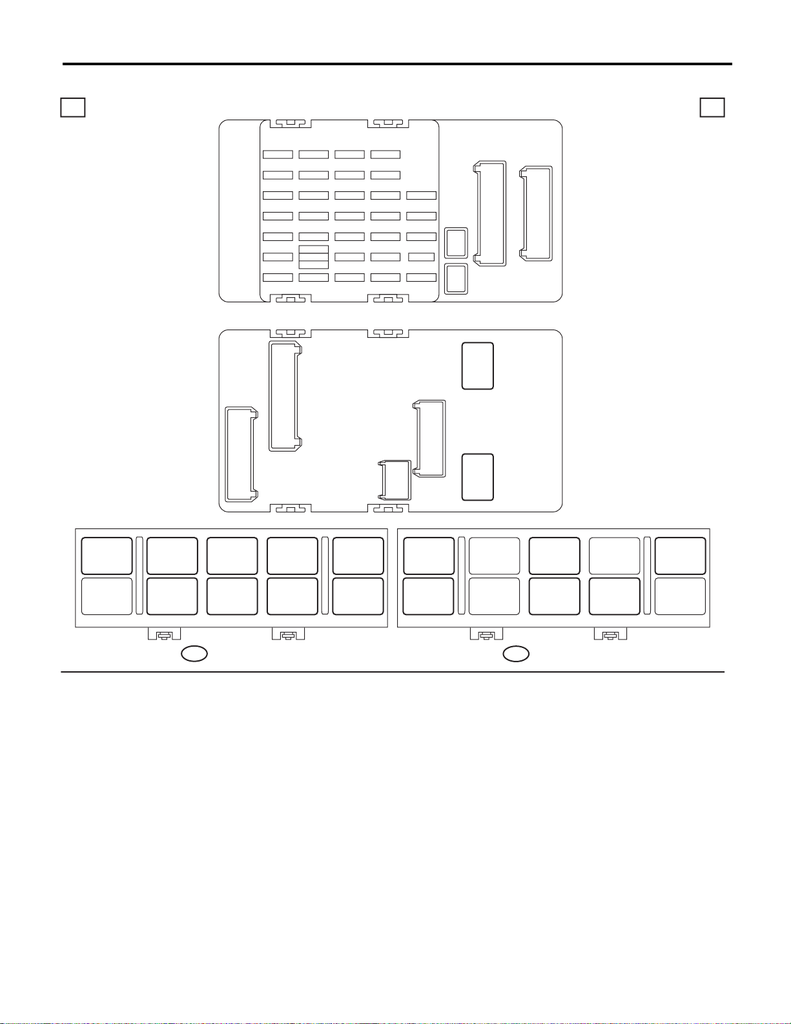

WI-27

Fuse And Relay

WIRING SYSTEM

8. ENGINE TYPE EJ (WITH PUSH BUTTON START, PASSENGER ROOM SIDE)

WI-44245

8a 8a

(3)

(4)

(5)

(6)

(8)

(9)

(7)

(13)

(11)

(10)

(14)

(16)

(15)

(17)

(12)

(1)

(2)

(1)

(2)

(6)(5)(4) (7)

(10)(9)(8) (11)

(13)(12)

(15)

(14)

(16) (17)

(3)

B225

B220

RELAY HOLDERRELAY HOLDER

No. 5

No. 4

No. 3

No. 2

No. 1

No. 12

No. 11

No. 10

No. 9

No. 8

No. 7

No. 6

No. 19

No. 18

No. 17

No. 16

No. 15

No. 14

No. 13

No. 26

No. 25

No. 24

No. 23

No. 22

No. 21

No. 20

No. 33

No. 32

No. 31

No. 30

No. 29

No. 28

No. 27

F/B FRONT SIDE

F/B BACK SIDE

ACCESSORY RELAY

IG 2 RELAY

FUEL PUMP RELAY

SEAT HEATER RELAY

FRONT FOG LIGHT RELAY

WIPER DEICER RELAY

DCCD RELAY

IG RELAY 1

STARTER CUT RELAY

MAIN RELAY

A/F, OXYGEN SENSOR RELAY

IG RELAY 2

STARTER RELAY (PUSH BUTTON START)

ELECTRONIC THROTTLE CONTROL RELAY

TAIL & ILLUMINATION RELAY

POWER WINDOW RELAY

STARTER RELAY 1